# DAPR2 Lecture 10 – RQ 1

```
library(tidyverse)

data1 <- read_csv("https://uoepsy.github.io/data/DapR2_S1B2_PracticalPart1.csv")
```

**RQ1: Does conscientiousness, frequency of access to online materials, and year of study in University predict course attendance?**

# Phase 1

## Identify the relevant variables

- outcome: course attendance, `Attendance`
- predictors:
  - consc `Conscientiousness`
  - freq of access `OnlineAccess`
  - year of study `Year`

## Data tidying

```
is.na(data1) |> table()
```

```
FALSE
 2382
```

```
data1 <- data1 |>
  mutate(
    Conscientiousness = factor(Conscientiousness, levels = c('Moderate', 'High', 'Low')),
    OnlineAccess = factor(OnlineAccess, levels = c('Sometimes', 'Often', 'Rarely')),
    Year = factor(Year, c('Y1', 'Y2', 'Y3', 'Y4', 'MSc', 'PhD'))
  )
```

```
str(data1)
```

```
tibble [397 × 6] (S3: tbl_df/tbl/data.frame)
 $ pid              : num [1:397] 1 2 3 4 5 6 7 8 9 10 ...
 $ Attendance       : num [1:397] 9 10 0 8 6 6 9 14 5 10 ...
 $ Conscientiousness: Factor w/ 3 levels "Moderate","High",..: 2 2 3 3 2 2 1 2 3 3 ...
 $ Time             : chr [1:397] "3PM" "2PM" "10AM" "4PM" ...
 $ OnlineAccess     : Factor w/ 3 levels "Sometimes","Often",..: 2 2 3 2 1 1 2 1 3 2 ...
 $ Year             : Factor w/ 6 levels "Y1","Y2","Y3",..: 3 3 2 4 1 1 5 1 1 3 ...
```

## Get summary statistics

- outcome: course attendance, `Attendance` – continuous
- predictors:
  - consc `Conscientiousness` – categ
  - freq of access `OnlineAccess` – categ
  - year of study `Year` – categ

```
psych::describe(data1$Attendance)
```

|  | vars | n | mean | sd | median | trimmed | mad | min | max | range | skew | kurtosis | se |
| --- | --- | --- | --- | --- | --- | --- | --- | --- | --- | --- | --- | --- | --- |
| X1 | 1 | 397 | 28.28 | 13.99 | 29 | 28.31 | 16.31 | 0 | 60 | 60 | -0.03 | -1 | 0.7 |

```
table(data1$Conscientiousness)
```

```
Moderate     High      Low
     146      124      127
```

Mode = Moderate.

```
table(data1$OnlineAccess)
```

```
Sometimes     Often    Rarely
      170       126       101
```

Mode = Sometimes.

```
table(data1$Year)
```

```
 Y1  Y2  Y3  Y4 MSc PhD
 89 100  66  71  48  23
```

Mode = Y2.

## Plot each variable individually

- outcome: course attendance, `Attendance` – continuous

```
data1 |>
  ggplot(aes(x = Attendance)) +
  geom_histogram()
```

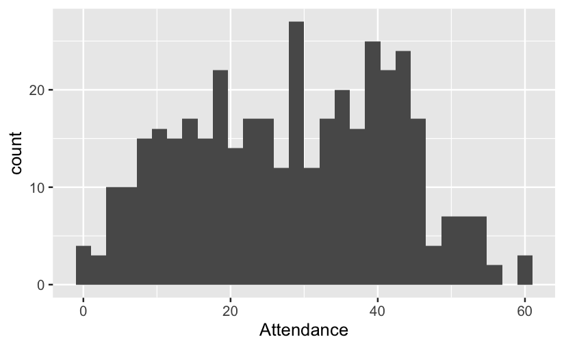

- predictors:
  - consc `Conscientiousness` – categ

```
data1 |>
  ggplot(aes(x = Conscientiousness, fill = Conscientiousness)) +
  geom_bar() +
  theme(legend.position = 'none')
```

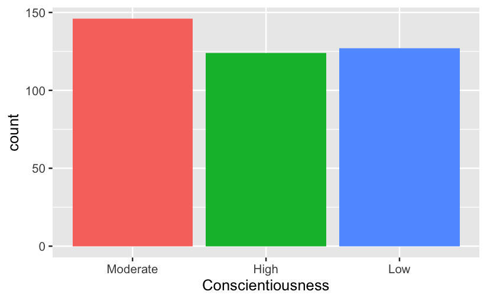

- freq of access `OnlineAccess` – categ

```
data1 |>
  ggplot(aes(x = OnlineAccess, fill = OnlineAccess)) +
  geom_bar() +
  theme(legend.position = 'none')
```

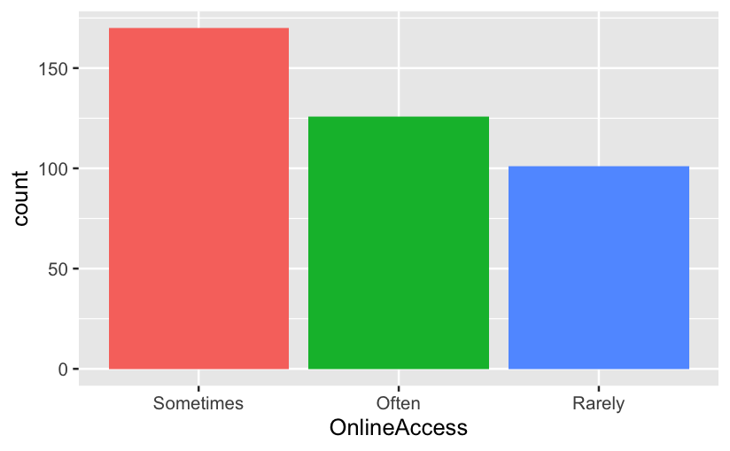

- year of study `Year` – categ

```
data1 |>
  ggplot(aes(x = Year, fill = Year)) +
  geom_bar() +
  theme(legend.position = 'none')
```

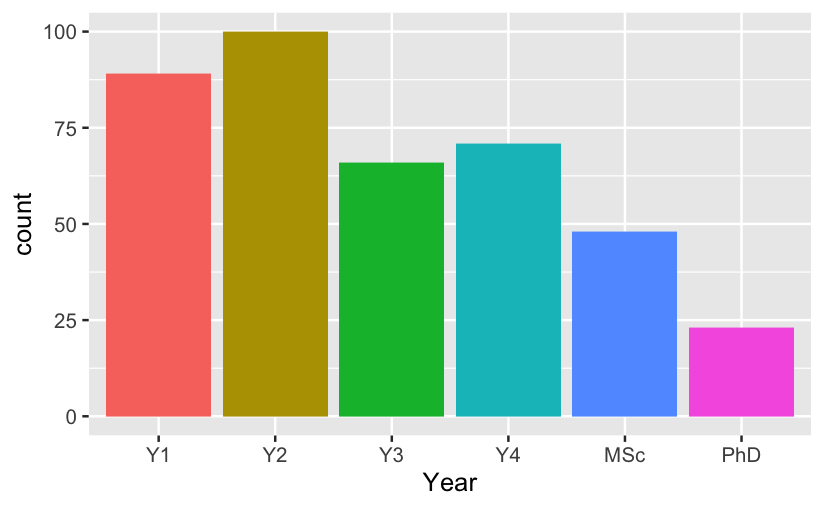

## Plot variables together

predictor = x axis – x3 for our three predictors

outcome = y axis – Attendance

```
data1 |>
  ggplot(aes(x = Conscientiousness, y = Attendance, colour = Conscientiousness, fill = Conscientiousness)) +
  geom_violin(alpha = 0.5) +
  geom_jitter() +
  theme(legend.position = 'none')
```

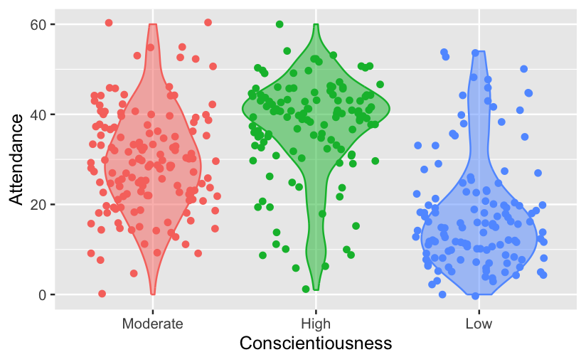

```
data1 |>
  ggplot(aes(x = OnlineAccess, y = Attendance, colour = OnlineAccess, fill = OnlineAccess)) +
  geom_violin(alpha = 0.5) +
  geom_jitter() +
  theme(legend.position = 'none')
```

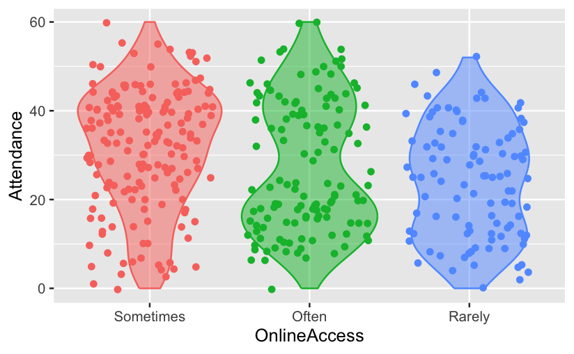

```
data1 |>
  ggplot(aes(x = Year, y = Attendance, colour = Year, fill = Year)) +
  geom_violin(alpha = 0.5) +
  geom_jitter() +
  theme(legend.position = 'none') +
  stat_summary(fun = mean, geom = 'point', colour = 'black')
```

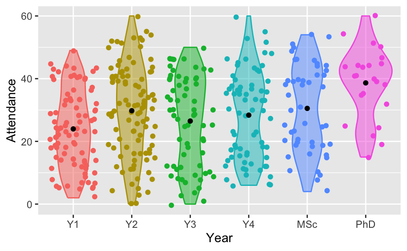

**RQ1: Does conscientiousness, frequency of access to online materials, and year of study in University predict course attendance?**

everyday / colloquial:

- H0: there’s no association between conscientiousness OR frequency of access OR year of study and course attendance.
- H1: there is an association between conscientiousness OR frequency of access OR year of study and course attendance.

a bit more formal:

- H0: the association between attendance and consc. OR freq. OR year is equal to 0.
- H1: the association between attendance and consc. OR freq. OR year is not equal to 0.

in mathematical notation:

first we have to define the linear expression that our model is gonna be based on.

(for that, we need to know how the predictors will be coded)

```
contrasts(data1$Conscientiousness)
```

```
         High Low
Moderate    0   0
High        1   0
Low         0   1
```

- two predictors: one called ConscHigh and one called ConscLow
  - ConscHigh: compare Moderate to High
  - ConscLow: compare Moderate to Low

```
contrasts(data1$OnlineAccess)
```

```
          Often Rarely
Sometimes     0      0
Often         1      0
Rarely        0      1
```

- OnlineAccessOften: Sometimes to Often
- OnlineAccessRarely: Sometimes to Rarely

```
contrasts(data1$Year)
```

```
    Y2 Y3 Y4 MSc PhD
Y1   0  0  0   0   0
Y2   1  0  0   0   0
Y3   0  1  0   0   0
Y4   0  0  1   0   0
MSc  0  0  0   1   0
PhD  0  0  0   0   1
```

- YearY2: Y1 compared to Y2
- YearY3: Y1 compared to Y3
- …
- YearPhD: Y1 compared to PhD
- two predictors from Consc
- two predictors from OnlineAccess
- five predictors from Year

beta0 and nine other betas

$$\text{Attendance} = \beta_0 + (\beta_1 \cdot C_{\text{High}})
+ (\beta_2 \cdot C_{\text{Low}})
+ (\beta_3 \cdot OA_{\text{Often}})
+ (\beta_4 \cdot OA_{\text{Rarely}}) + \\
(\beta_5 \cdot Y_{\text{Y2}})
+ (\beta_6 \cdot Y_{\text{Y3}})
+ (\beta_7 \cdot Y_{\text{Y4}})
+ (\beta_8 \cdot Y_{\text{MSc}})
+ (\beta_9 \cdot Y_{\text{PhD}}) + \epsilon$$
where C = Conscientiousness, OA = Online Access, Y = Year.

$$H0 : \text{All} ~ \beta_j = 0 ~ \text{(for j = 1, 2, 3, 4, 5, 6, 7, 8,
9)} \\
H1 : \text{At least one} ~ \beta_j \neq 0 ~ \text{(for j = 1, 2, 3, 4,
5, 6, 7, 8, 9)} \\$$

$$\begin{align}
H0 &: \text{All} ~ \beta_j = 0 ~ \text{(for j = 1, 2, 3, 4, 5, 6, 7,
8, 9)} \\
H1 &: \text{At least one} ~ \beta_j \neq 0 ~ \text{(for j = 1, 2, 3,
4, 5, 6, 7, 8, 9)} \\
\end{align}$$

# Phase 2

```
m1
```

```
Call:
lm(formula = Attendance ~ Conscientiousness + OnlineAccess +
    Year, data = data1)

Coefficients:
          (Intercept)  ConscientiousnessHigh   ConscientiousnessLow
               27.874                  7.366                -10.292
    OnlineAccessOften     OnlineAccessRarely                 YearY2
               -3.533                 -5.378                  4.574
               YearY3                 YearY4                YearMSc
                3.418                  4.266                  5.649
              YearPhD
               12.484
```

# Phase 3

## Interpret the model coefficients

```
summary(m1)
```

```
Call:
lm(formula = Attendance ~ Conscientiousness + OnlineAccess +
    Year, data = data1)

Residuals:
    Min      1Q  Median      3Q     Max
-37.657  -6.990  -0.279   6.085  31.844

Coefficients:
                      Estimate Std. Error t value Pr(>|t|)
(Intercept)             27.874      1.533  18.179  < 2e-16 ***
ConscientiousnessHigh    7.366      1.392   5.292 2.03e-07 ***
ConscientiousnessLow   -10.292      1.399  -7.359 1.12e-12 ***
OnlineAccessOften       -3.533      1.339  -2.639 0.008649 **
OnlineAccessRarely      -5.378      1.441  -3.732 0.000218 ***
YearY2                   4.574      1.657   2.760 0.006049 **
YearY3                   3.418      1.853   1.844 0.065926 .
YearY4                   4.266      1.817   2.347 0.019418 *
YearMSc                  5.649      2.046   2.760 0.006051 **
YearPhD                 12.484      2.661   4.692 3.76e-06 ***
---
Signif. codes:  0 ‘***’ 0.001 ‘**’ 0.01 ‘*’ 0.05 ‘.’ 0.1 ‘ ’ 1

Residual standard error: 11.35 on 387 degrees of freedom
Multiple R-squared:  0.3574,    Adjusted R-squared:  0.3424
F-statistic: 23.91 on 9 and 387 DF,  p-value: < 2.2e-16
```

Intercept: mean attendance when everything is at its reference level, so: when C = Moderate, OA = Sometimes, Y = Y1. 27.9 mean attendance for that subset of the data.

ConscientiousnessHigh: the difference in mean attendance between Intercept and when C = High. So when OA = Sometimes, Y = Y1, then there’s a difference in attendance of about 7.4. attendance goes up when OA = Sometimes and Y = Y1 have higher conscientiousness. and this difference is significant at alpha = 0.05. - key: all the variables that aren’t at issue are held constant at their reference level.

OnlineAccessOften: when C = Moderate, Y = Y1, the difference in mean attendance from OA = Sometimes to OA = Often is -3.5. that means that when people access online material more often, attendance goes down. mean attendance for this group of people (OA = Often) is 27.9 - 3.5 = 24.4. significant difference.

YearY2: when C = Moderate, when OA = Sometimes, diff between Y1 and Y2 attendance is 4.6. 27.9 + 4.6 = something over 30. and the diff is significant.

## Check model assumptions

L linearity

- we can assume linearity because we’ve got categorical predictors.

I independence of errors

- we can assume independence of errors because data from between-subjects design.

N normality of errors

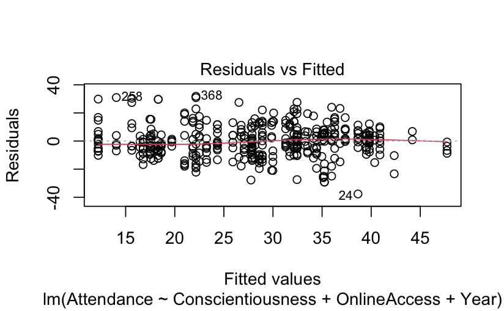

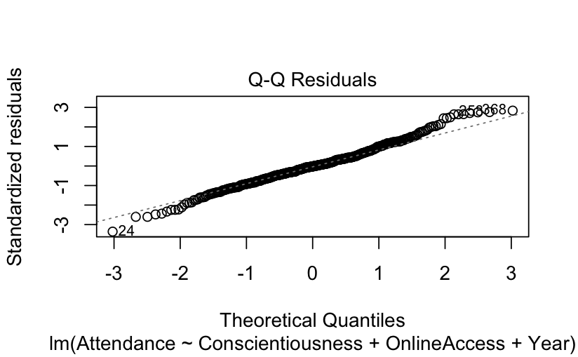

no cause for concern.

E equal variance of errors

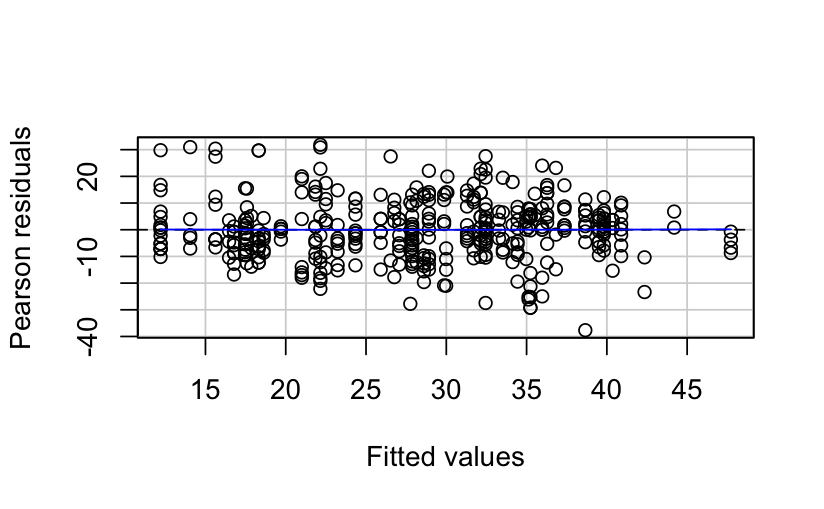

- no fan/funnel structure
- good to go

## Multicollinearity

correlations between the predictors.

```
car::vif(m1)
```

```
                      GVIF Df GVIF^(1/(2*Df))
Conscientiousness 1.041823  2        1.010296
OnlineAccess      1.030371  2        1.007508
Year              1.044315  5        1.004346
```

no multicollinearity.

## emmeans

```
emmeans::emmeans(m1, ~ Conscientiousness + OnlineAccess + Year)
```

```
 Conscientiousness OnlineAccess Year emmean   SE  df lower.CL upper.CL
 Moderate          Sometimes    Y1     27.9 1.53 387    24.86     30.9
 High              Sometimes    Y1     35.2 1.63 387    32.03     38.4
 Low               Sometimes    Y1     17.6 1.66 387    14.31     20.8
 Moderate          Often        Y1     24.3 1.66 387    21.07     27.6
 High              Often        Y1     31.7 1.75 387    28.27     35.1
 Low               Often        Y1     14.0 1.72 387    10.66     17.4
 Moderate          Rarely       Y1     22.5 1.67 387    19.20     25.8
 High              Rarely       Y1     29.9 1.79 387    26.35     33.4
 Low               Rarely       Y1     12.2 1.69 387     8.89     15.5
 Moderate          Sometimes    Y2     32.4 1.47 387    29.56     35.3
 High              Sometimes    Y2     39.8 1.53 387    36.81     42.8
 Low               Sometimes    Y2     22.2 1.63 387    18.95     25.4
 Moderate          Often        Y2     28.9 1.60 387    25.76     32.1
 High              Often        Y2     36.3 1.65 387    33.03     39.5
 Low               Often        Y2     18.6 1.69 387    15.29     22.0
 Moderate          Rarely       Y2     27.1 1.67 387    23.79     30.3
 High              Rarely       Y2     34.4 1.74 387    31.01     37.9
 Low               Rarely       Y2     16.8 1.71 387    13.42     20.1
 Moderate          Sometimes    Y3     31.3 1.77 387    27.81     34.8
 High              Sometimes    Y3     38.7 1.77 387    35.18     42.1
 Low               Sometimes    Y3     21.0 1.75 387    17.56     24.4
 Moderate          Often        Y3     27.8 1.86 387    24.11     31.4
 High              Often        Y3     35.1 1.85 387    31.49     38.8
 Low               Often        Y3     17.5 1.78 387    13.97     21.0
 Moderate          Rarely       Y3     25.9 1.91 387    22.15     29.7
 High              Rarely       Y3     33.3 1.93 387    29.48     37.1
 Low               Rarely       Y3     15.6 1.79 387    12.09     19.2
 Moderate          Sometimes    Y4     32.1 1.67 387    28.85     35.4
 High              Sometimes    Y4     39.5 1.72 387    36.13     42.9
 Low               Sometimes    Y4     21.8 1.73 387    18.45     25.2
 Moderate          Often        Y4     28.6 1.74 387    25.19     32.0
 High              Often        Y4     36.0 1.78 387    32.48     39.5
 Low               Often        Y4     18.3 1.74 387    14.90     21.7
 Moderate          Rarely       Y4     26.8 1.91 387    23.01     30.5
 High              Rarely       Y4     34.1 1.97 387    30.26     38.0
 Low               Rarely       Y4     16.5 1.86 387    12.81     20.1
 Moderate          Sometimes    MSc    33.5 1.95 387    29.70     37.3
 High              Sometimes    MSc    40.9 1.91 387    37.13     44.7
 Low               Sometimes    MSc    23.2 1.98 387    19.34     27.1
 Moderate          Often        MSc    30.0 2.00 387    26.05     33.9
 High              Often        MSc    37.4 1.97 387    33.48     41.2
 Low               Often        MSc    19.7 1.99 387    15.79     23.6
 Moderate          Rarely       MSc    28.1 2.15 387    23.93     32.4
 High              Rarely       MSc    35.5 2.13 387    31.31     39.7
 Low               Rarely       MSc    17.9 2.09 387    13.75     22.0
 Moderate          Sometimes    PhD    40.4 2.53 387    35.38     45.3
 High              Sometimes    PhD    47.7 2.58 387    42.65     52.8
 Low               Sometimes    PhD    30.1 2.69 387    24.78     35.3
 Moderate          Often        PhD    36.8 2.60 387    31.72     41.9
 High              Often        PhD    44.2 2.65 387    38.99     49.4
 Low               Often        PhD    26.5 2.71 387    21.20     31.9
 Moderate          Rarely       PhD    35.0 2.64 387    29.79     40.2
 High              Rarely       PhD    42.3 2.70 387    37.03     47.7
 Low               Rarely       PhD    24.7 2.72 387    19.34     30.0

Confidence level used: 0.95
```

[figure not shown]